# facet

Martin S. Bjørnerem

9 desember 2018

## Vårt prosjekt: Bitcoin og aksjemarkeder

### Introduksjon

Vi ønsker å undersøke om prisutviklingen på bitcoin er relatert til kursene på verdens aksjemarkeder. Vi har hentet daglig data for bitcoin i USD (BTC/USD) og s&p500 så langt bak i tid som mulig. Siden BTC kan kjøpes og selges hele uka, også i helgene, mens børsnoterte aksjer kun handles mandag-fredag.Stolpediagrammet nedenfor viser gjennomsnitts- og median-pris for bitcoin fordelt på de ulike ukedagene. I tillegg har vi foretatt en t-test for å sjekke om forskjellene i gjennomsnit for ukedager og helger er statistisk signifikante.

Dra inn flere prediktorvariabler som olje og statsobligasjonsrenter for å gjennomføre en multippel regresjonsanalyse på aksjeindeksene.

### Første blikk/intrykk av bitcoin data

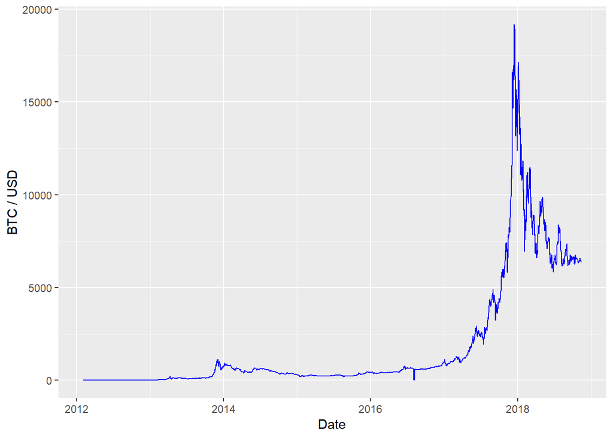

```
##       Date                 BTC
##  Min.   :2012-02-02   Min.   :    0.0
##  1st Qu.:2013-10-09   1st Qu.:  138.6
##  Median :2015-06-18   Median :  438.7
##  Mean   :2015-06-22   Mean   : 1857.0
##  3rd Qu.:2017-03-09   3rd Qu.: 1125.3
##  Max.   :2018-11-14   Max.   :19187.0
```

```
## # A tibble: 4 x 2
##   Date         BTC
##   <date>     <dbl>
## 1 2016-08-03     0
## 2 2016-08-04     0
## 3 2016-08-05     0
## 4 2016-08-06     0
```

Grafen viser det ikke, men ved et kall på summary() av dataen ser vi at minimumsprisen på bitcoin er 0. Det viser det seg at datasettet har prisen 0 fire sammenhengende dager i august 2016. Vi mener at verdien 0 representerer at dataen er manglende. Datasettet filtreres slik at alle verdier er høyere enn 0.

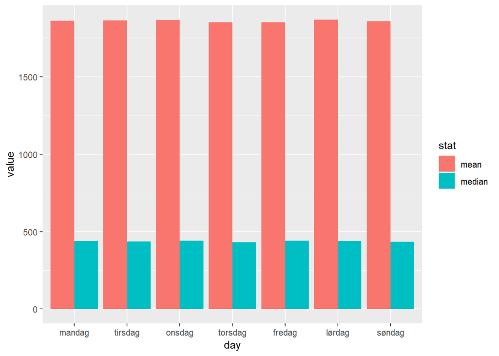

```
##
##  Two Sample t-test
##
## data:  BTC by type
## t = 0.036563, df = 2455, p-value = 0.9708
## alternative hypothesis: true difference in means is not equal to 0
## 95 percent confidence interval:
##  -276.1912  286.6864
## sample estimates:
##   mean in group helg mean in group ukedag
##             1863.783             1858.535
```

Stolpediagrammet viser at forskjellene er minimale, men for sikkerhets skyld foretar vi en t-test for å teste om gjenomsnittene for ukedager og helg er signifikant forskjellig. Nullhypotese: Ingen forskjell i gjennomsnitt for ukedager og helger. Forutsetter lik varians.

p-verdien fra testen er 0.97, noe som er svært høyt. Forskjellene er dermed ikke signifikante, uansett hvilket signifikansnivå vi velger. Ettersom forskjellene ikke er signifikante har vi valgt å fjerne observasjoner lørdager og søndager slik at vi kan “matche” datasettet til aksjeindeksene. En alternativ løsning kunne vært å omgjøre prisene og aksjekursene til ukentlig data.

```
##       Date                  SP
##  Min.   :1970-11-27   Min.   :  62.28
##  1st Qu.:1982-11-22   1st Qu.: 139.06
##  Median :1994-11-10   Median : 469.50
##  Mean   :1994-11-19   Mean   : 785.48
##  3rd Qu.:2006-11-16   3rd Qu.:1265.29
##  Max.   :2018-11-27   Max.   :2930.75
```

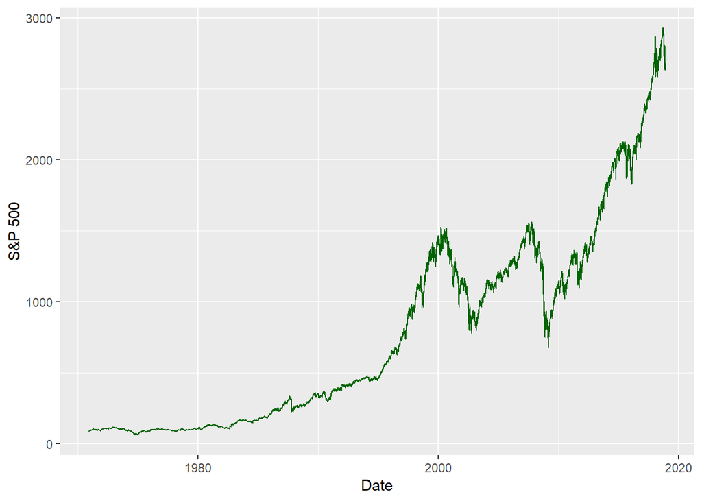

```
##       Date                  SH
##  Min.   :2001-11-08   Min.   :1012
##  1st Qu.:2006-03-02   1st Qu.:1668
##  Median :2010-05-31   Median :2397
##  Mean   :2010-06-02   Mean   :2490
##  3rd Qu.:2014-09-06   3rd Qu.:3090
##  Max.   :2018-12-07   Max.   :6092
```

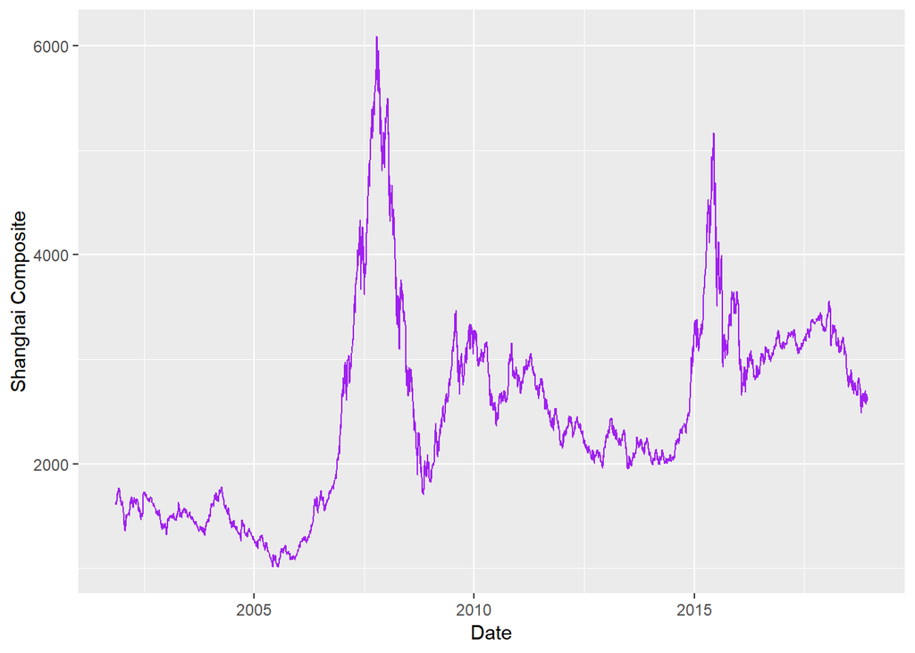

```
## # A tibble: 6 x 4
##   Date         BTC index value
##   <date>     <dbl> <chr> <dbl>
## 1 2012-02-02   6.1 SP    1326.
## 2 2012-02-03   6   SP    1345.
## 3 2012-02-06   5.4 SP    1344.
## 4 2012-02-07   5.7 SP    1347.
## 5 2012-02-08   5.6 SP    1350.
## 6 2012-02-09   5.8 SP    1352.
```

```
## # A tibble: 6 x 4
##   Date         BTC index value
##   <date>     <dbl> <chr> <dbl>
## 1 2018-11-07 6573. SH    2641.
## 2 2018-11-08 6480. SH    2636.
## 3 2018-11-09 6420. SH    2599.
## 4 2018-11-12 6447. SH    2631.
## 5 2018-11-13 6464. SH    2655.
## 6 2018-11-14 6359. SH    2632.
```

Summary() av datasettene for aksjeindeksene viser ingen manglende verdier eller nullverdier. Dataen inner_joines på dato som er felles for alle datasett. Inner_join matcher bare dato hvor alle datasettene har verdier. I tillegg omgjør vi datasettet fra “wide” til “long”. Hver dato har nå to observasjoner av BTC matchet med hver av indeksene i kolonnen “index”. Dataen strekker seg fra februar 2012 til november 2018.

## S&P 500 vs BTC og og Shanghai Composite vs BTC

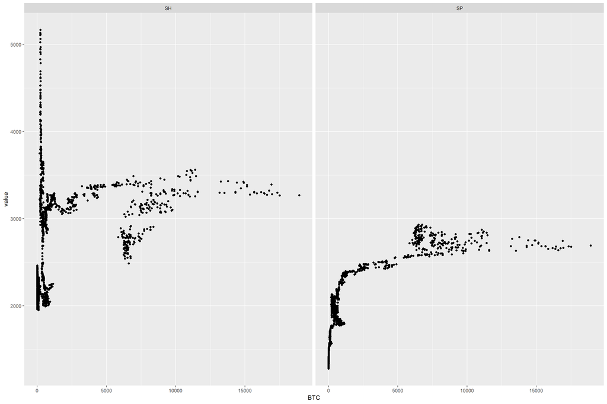

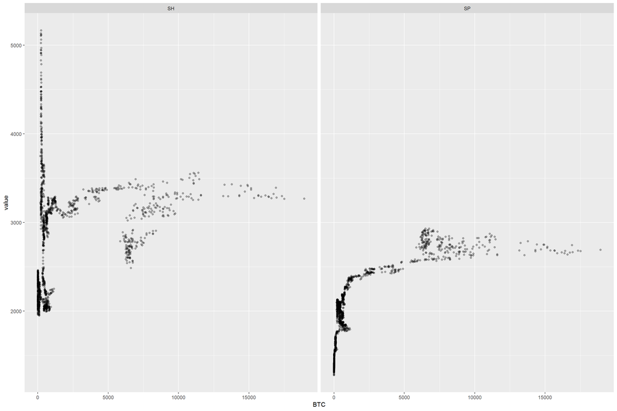

For S&P 500: Vi ser at variablene er relaterte, men at forholdet ikke er lineært. En lineær modell vil derfor ikke passe for tidsintervallet. S&P 500 mot log(BTC) gir en mye bedre fit. Vi kan tranformere observasjonene for bitcoin og lage en lineær modell for S&P som utrykk av logaritmeverdiene av bitcoin. I enkelte ggplot-grafer er en svært lav alpha benyttet for å vise den ekstreme overplottingen i nedre venstre hjørne.

```
##
## Call:
## lm(formula = SP ~ log(BTC), data = ukedager)
##
## Residuals:
##     Min      1Q  Median      3Q     Max
## -458.80  -82.06   25.51   91.56  345.30
##
## Coefficients:
##             Estimate Std. Error t value Pr(>|t|)
## (Intercept)  897.544     10.691   83.95   <2e-16 ***
## log(BTC)     192.252      1.691  113.71   <2e-16 ***
## ---
## Signif. codes:  0 '***' 0.001 '**' 0.01 '*' 0.05 '.' 0.1 ' ' 1
##
## Residual standard error: 141.7 on 1585 degrees of freedom
## Multiple R-squared:  0.8908, Adjusted R-squared:  0.8907
## F-statistic: 1.293e+04 on 1 and 1585 DF,  p-value: < 2.2e-16
```

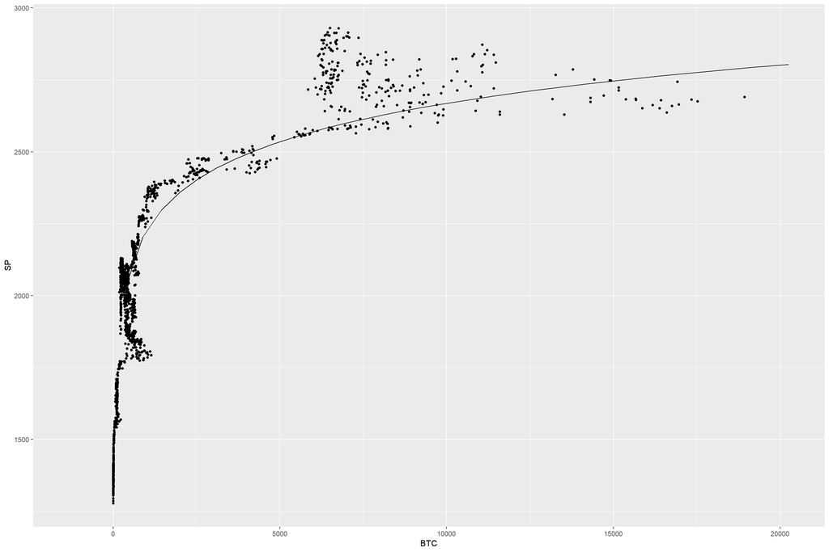

```
##
## Call:
## lm(formula = SH ~ log(BTC), data = ukedager)
##
## Residuals:
##     Min      1Q  Median      3Q     Max
## -890.17 -418.96   26.66  233.07 2427.46
##
## Coefficients:
##             Estimate Std. Error t value Pr(>|t|)
## (Intercept) 2051.507     42.579   48.18   <2e-16 ***
## log(BTC)     126.462      6.734   18.78   <2e-16 ***
## ---
## Signif. codes:  0 '***' 0.001 '**' 0.01 '*' 0.05 '.' 0.1 ' ' 1
##
## Residual standard error: 564.1 on 1585 degrees of freedom
## Multiple R-squared:  0.182,  Adjusted R-squared:  0.1815
## F-statistic: 352.7 on 1 and 1585 DF,  p-value: < 2.2e-16
```

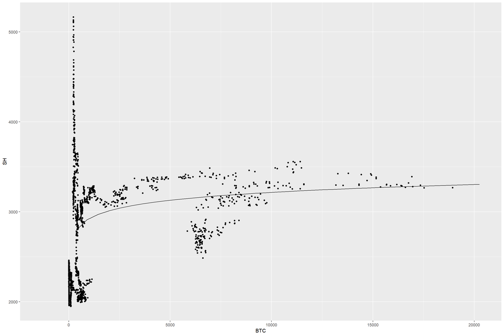

```
## [1] 0.9438229
```

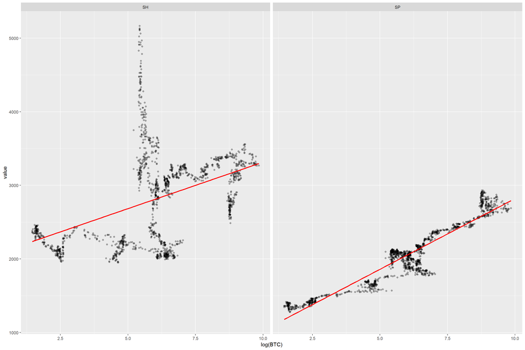

Begge indeksene har positive regresjonslinjer. Vi ser at forholdet er sterkere for S&P 500 enn Shangai Composite siden punktene ligger tettere rundt regresjonslinja. Det innebærer at summen av kvadratene blir mindre og at modellene har en bedre fit.

For S&P: Positiv korrelasjon innebærer at når den ene variabelen øker, øker også den andre. Styrken i forholdet er lik korrelasjonskoeffisienten, som er 0.94. Korrelasjonen er svært sterk og ikke langt unna perfekt. Ved perfekt korrelasjon er koeffisienten?? lik 1.

Hva sier regresjonsmodellen? R-squared er 0.89. 89% av variasjon i S&P 500 kan forklares av variasjon i log(BTC). For lineære modeller med kun en uavhengig variabel er verdien lik korrelasjonskoeffesienten opphøyet i 2.

For Shanghai: Forholdet er ikke like tydelig. En stor mengde observasjoner viser til store endringer i den kinesiske indeksen for de samme verdiene av log(BTC). Observasjonene svekker forholdet for den resterende dataen som følger trenden.

Vi er interessert i å se hvordan forholdet og korrelasjonen mellom indeksene og log av BTC har utviklet seg over tid.

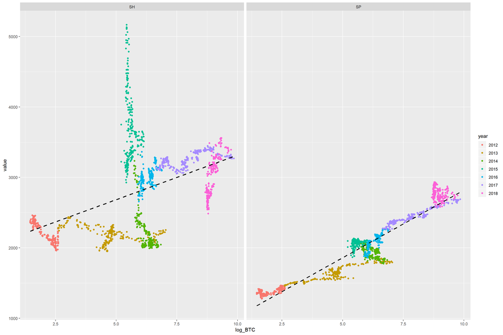

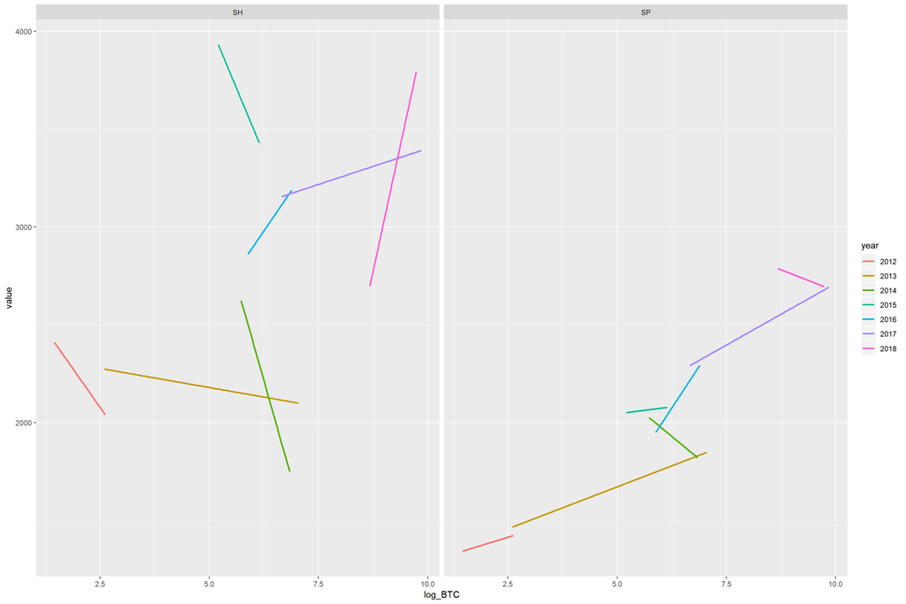

Legger til farge for ulike år for å vise utvikling i korrelasjon over tid.

For USA: I den andre grafen har hvert år fått en regresjonslinje fra egen lineær modell. Fra grafen ser vi at regresjonslinjene har negativt stigningstall i to årstall, 2014 og 2018. Begge de to årene opplevde bitcoin at “bobla sprakk”, uten at børsindeksene falt.

For Kina: Vi ser at spredningen i data og avstanden fra regresjnslinjen tyder på veldig stor volatilitet, noe som stemmer overrens med virkeligheten. Shanghai børsen nådde klimax i 2015 og har siden synket over 50%. Stort sette alle datapunktene for 2015 ligger overnfor regresjonslinjen, og i 2018 ser vi at flesteparten av dataen ligger under linjen noe som stemmer overrens med at Bitcoin har falt veldig i verdi i 2018.

# Glidende korrelasjon

Vi har benyttet 200 dagers glidende korrelasjon. Korrelasjonen på 200 dager flyttes mot høyre. Enhver observasjonen er et resultat av de siste 200 dagene. De 200 første observasjonene “forsvinner” dermed da de ikke har en verdi.

[output not shown]

```
## [1] 0.421458
```

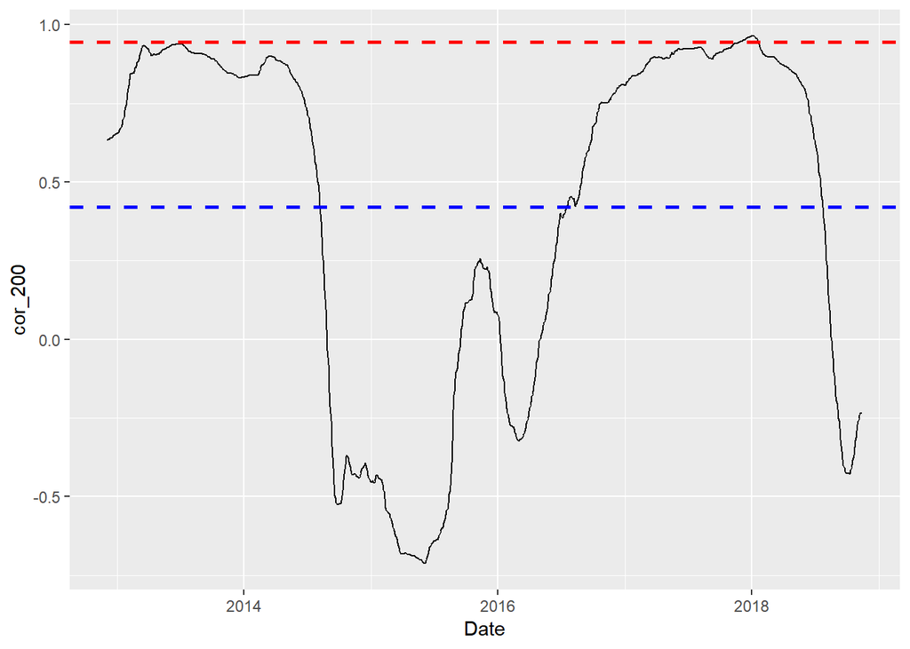

```
## [1] 0.4266502
```

```
## [1] -0.05814605
```

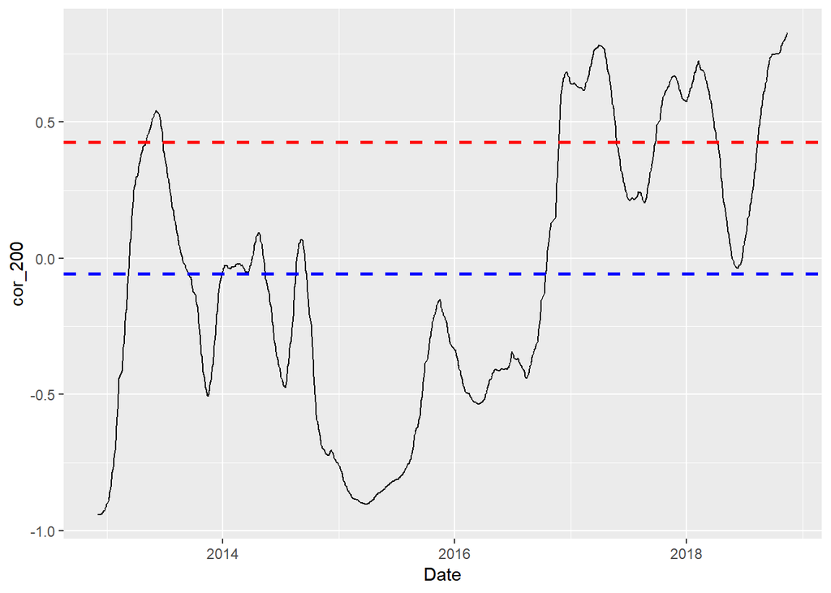

Den gjennomsnittlige korrelasjonen er høyere enn gjennomsnittet av den 200-dagers glidende korrelasjonen. Dette gjelder både for den amerikanske og kinesiske indeksen.

## Multippel regresjonsmodell:

```
## # A tibble: 6 x 7
##   Date        ch1y   oil  us3m    SH    SP   BTC
##   <date>     <dbl> <dbl> <dbl> <dbl> <dbl> <dbl>
## 1 2018-11-14  2.60  56.2  2.38 2632. 2702. 6359.
## 2 2018-11-13  2.62  55.7  2.35 2655. 2722. 6464.
## 3 2018-11-12  2.66  59.9  2.36 2631. 2726. 6447.
## 4 2018-11-09  2.69  60.2  2.36 2599. 2781. 6420.
## 5 2018-11-08  2.72  60.7  2.36 2636. 2807. 6480.
## 6 2018-11-07  2.76  61.7  2.36 2641. 2814. 6573.
```

## For USA:

```r
multifit.sp <- lm(formula = SP ~ oil + us3m + log(BTC), data = multi)
summary(multifit.sp)
```

```
##
## Call:
## lm(formula = SP ~ oil + us3m + log(BTC), data = multi)
##
## Residuals:
##      Min       1Q   Median       3Q      Max
## -301.652  -54.135   -4.037   60.149  211.335
##
## Coefficients:
##              Estimate Std. Error t value Pr(>|t|)
## (Intercept) 1433.7085    13.7948  103.93   <2e-16 ***
## oil           -3.4270     0.1068  -32.09   <2e-16 ***
## us3m         210.4993     4.9347   42.66   <2e-16 ***
## log(BTC)     126.3672     1.6660   75.85   <2e-16 ***
## ---
## Signif. codes:  0 '***' 0.001 '**' 0.01 '*' 0.05 '.' 0.1 ' ' 1
##
## Residual standard error: 87.11 on 1581 degrees of freedom
## Multiple R-squared:  0.9587, Adjusted R-squared:  0.9586
## F-statistic: 1.224e+04 on 3 and 1581 DF,  p-value: < 2.2e-16
```

## Oppsummering av S&P 500 og BTC

S&P 500 er sterkt korrelert med BTC. Transformering av bitcoinprisen til logaritmeverdier viser en sterk og positiv korrelasjon.

## For Kina:

```
##
## Call:
## lm(formula = SH ~ oil + ch1y + log(BTC), data = multi)
##
## Residuals:
##    Min     1Q Median     3Q    Max
## -893.6 -195.9  -57.2  118.1 2092.7
##
## Coefficients:
##              Estimate Std. Error t value Pr(>|t|)
## (Intercept) 4147.5992    59.2028  70.058  < 2e-16 ***
## oil          -18.8436     0.6331 -29.766  < 2e-16 ***
## ch1y         -69.4919    25.2339  -2.754  0.00596 **
## log(BTC)      32.5188     6.7827   4.794 1.78e-06 ***
## ---
## Signif. codes:  0 '***' 0.001 '**' 0.01 '*' 0.05 '.' 0.1 ' ' 1
##
## Residual standard error: 384.6 on 1581 degrees of freedom
## Multiple R-squared:  0.6203, Adjusted R-squared:  0.6195
## F-statistic: 860.8 on 3 and 1581 DF,  p-value: < 2.2e-16
```

Svakheten i dataen skal vi illustrere videre i oppgaven ved å analysere samme data, men over ulike tidshoisonter. Bitcoin dataen er over en relativ kort tidshorisont, og hele perioden sammenfaller med bullmarket i USA etter finanaskrisen, det kan gjøre at dataen får en urelatert positiv korrelasjon.

```
##       ch1y   oil  us3m   BTC    SP    SH
## ch1y  1.00  0.41  0.16  0.31  0.16 -0.31
## oil   0.41  1.00 -0.29 -0.20 -0.57 -0.78
## us3m  0.16 -0.29  1.00  0.85  0.83  0.25
## BTC   0.31 -0.20  0.85  1.00  0.75  0.27
## SP    0.16 -0.57  0.83  0.75  1.00  0.57
## SH   -0.31 -0.78  0.25  0.27  0.57  1.00
```

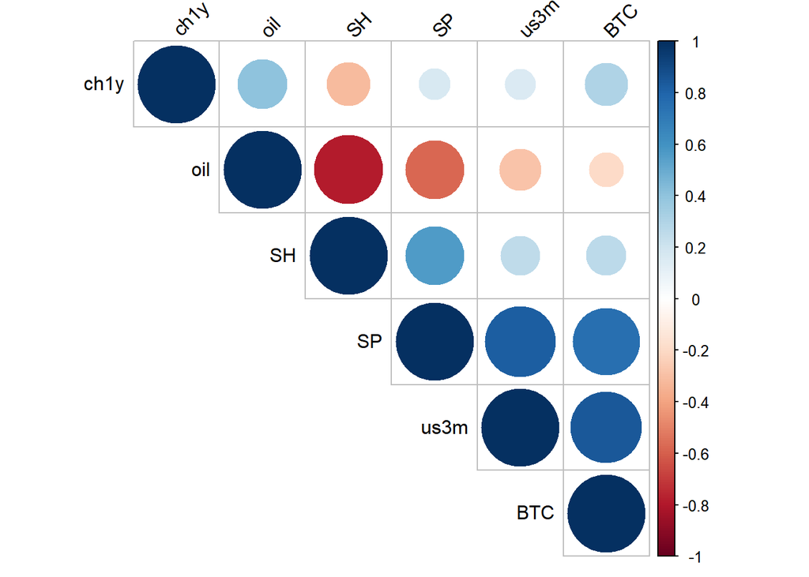

Her ser vi en korrelasjons matrix på viktige faktorer i finansmarkedene i USA og Kina. Vi har valgt å tatt med USA 3 month treassury bonds, og Kinesiske 1 year bonds. Disse blir ansett for å være benchmarken rente for risikofri kapital, og er dermed viktig i verdsettingen av eiendeler.

Her ser vi oljeprisen negative utvikling på finansmarkedene. Det skjer ved at en økning i pris på en viktig innsatsfaktor (olje) prises inn markede ved å redusere akjskurser siden økt oljepris redusert fri egenkapital hos bedrifter.

[output not shown]

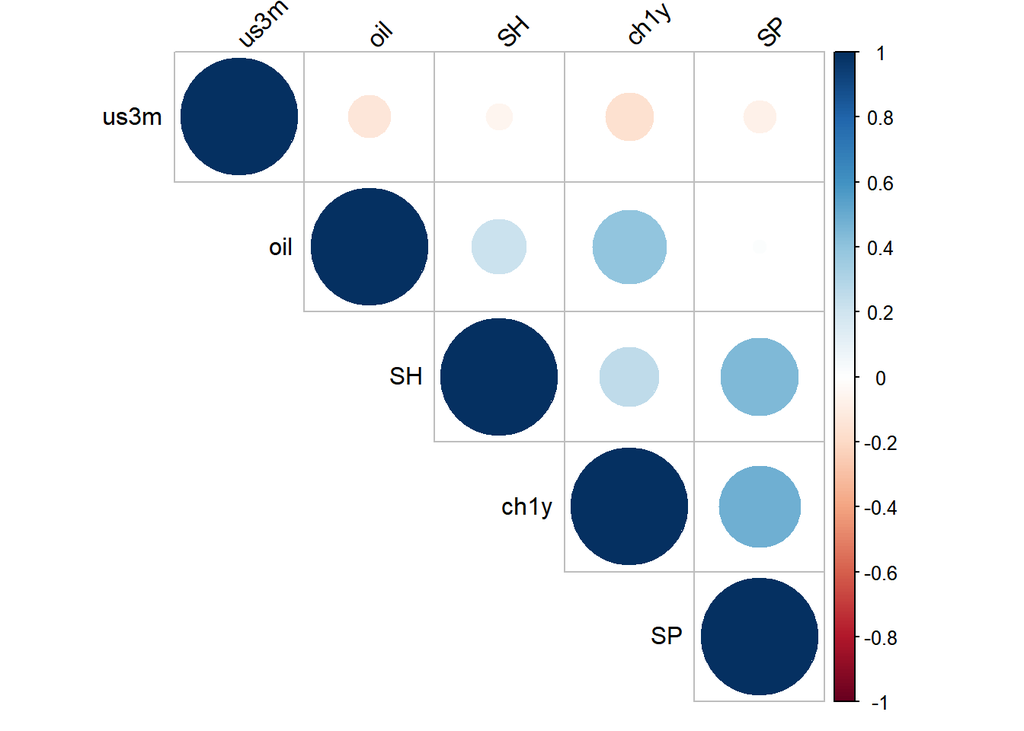

Vi ser her at korrelasjonene er mye svakere når tidshorisonten øker. Vi ønsker dermed å se på differansen i korrelasjon når vi har forskjellige lenge på dataen ved å lage en differanse korrelasjon matrix.

```
##              ch1y          oil       us3m         SP         SH
## ch1y  0.000000000  0.009531925  0.3271831 -0.3198378 -0.5729005
## oil   0.009531925  0.000000000 -0.1556721 -0.5877386 -1.0020623
## us3m  0.327183055 -0.155672143  0.0000000  0.9067217  0.3053085
## SP   -0.319837788 -0.587738553  0.9067217  0.0000000  0.1233147
## SH   -0.572900452 -1.002062305  0.3053085  0.1233147  0.0000000
```

Her ser vi en korrelasjon differanse matrix når vi analyserer korrelasjoner i tidsperiodene 2012-2018 og 2002-2018. Differanse matrixen kunne dessverre ikke vises grafisk siden enkelte differanser i korrelasjon var større enn 1 eller -1 og korrelasjoner kan kun utrykkes innenfor det intervallet.

# Konklusjon

Ut fra dataen tyder det på at det amrikanske markedet er tetter knyttet opp mot bitcoin. USA er også verdens største øknomi og USAs BNP er 40% større en Kinas. Da er det kanskje ikke så unaturlig at utvillingen i det amerikanske markede påvirker Bitcoin mer enn Kinas.

## Svakheter/utfordringer

Utfordringen i vår analyse er tidshorisont. Datasette til bitcoin strekker seg tilbake til 2012, fordi det var da det startet å bli handlet.

Sterk korrelasjon er ikke en indikator på årsakssammenhen eller kausalitet.